# Chapter Fourteen: Approaches to Missing and Censored Data in Biomarker Research

This R Markdown document accompanies the chapter Approaches to Missing and Censored Data in Biomarker Research (Audigier, Geronimi 2026) and provides practical examples for implementing the methods discussed using R. It illustrates key approaches for handling missing and censored biomarker data through reproducible code and real-data–inspired examples. Readers are encouraged to explore and adapt the code to their own applications.

## The case of omics data

NCI60 data contains expressions levels on p=6830 genes from n=64 cancer cells lines (Ross et al, 2000). Cells can be divided into K=14 cancer types. To illustrate multivariate exploratory methods on incomplete data, 30% of the values are generated to be missing with missing values are artificially added according to a MCAR mechanism. Then, iterative PCA is performed using d=16 dimensions (number estimated using cross-validation).

### Principal components

```r
## number of components (time consumming)
# res.ncp <- estim_ncpPCA(xxna,
#                     ncp.min = 5,
#                     ncp.max = 20,
#                     scale = TRUE,
#                     method.cv = "Kfold",
#                     nbsim = 10,
#                     verbose = TRUE)
# ncp <- 16
# res.imp <- imputePCA(xxna, ncp = ncp, scale = TRUE)
# res.pca <- PCA(res.imp$completeObs, graph = FALSE)
#save(res.ncp, res.imp, res.pca, file = "pca_results.RData")
load("data/pca_results.RData")

## Figure 15.1
col <- gray.colors(k)
names(col) <- unique(nci.lab)
col <- col[nci.lab]
names(col) <- NULL

#png("iterativepca.png", res=300,width=2000, height=2000)
plot.new()
```

[output not shown]

```r
plot(res.pca,
     choix = "ind",
     col.ind = col,
     graph.type="classic",
     label = "none",
     cex=1.5)
```

[output not shown]

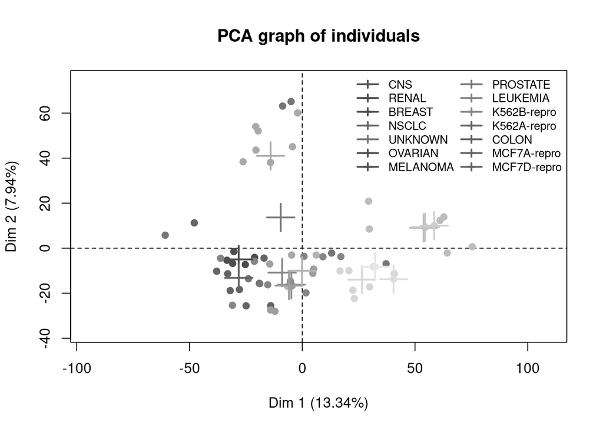

```r
B <- array2DF(by(res.pca$ind$coord[,1:2],INDICES =  col,FUN = colmeans), simplify = TRUE)
points(B[,2:3],col=B[,1],pch=3,cex=3,lwd=2)
legend("topright", pch = 3,cex = .8, lwd = 2,legend = unique(nci.lab), ncol = 2, bty = "n", col = col)
```

```r
#dev.off()
```

```r
#png("pca.png", res=300,width=2000, height=2000)
res.pca.full <- PCA(nci.data, graph=FALSE)
plot.new()
```

[output not shown]

```r
plot(res.pca.full,
     choix = "ind",
     col.ind = col,
     graph.type="classic",
     label = "none",
     cex=1.5)
```

[output not shown]

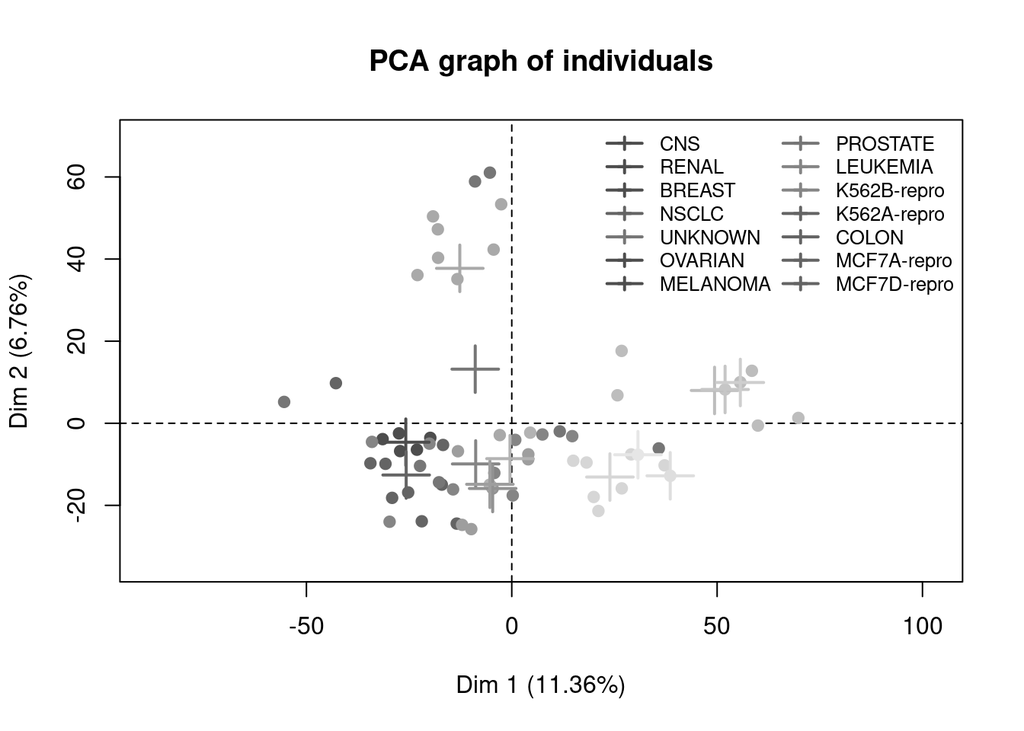

```r
B <- array2DF(by(res.pca.full$ind$coord[,1:2],INDICES =  col,FUN = colmeans), simplify = TRUE)
points(B[,2:3],col=B[,1],pch=3,cex=3,lwd=2)
legend("topright", pch = 3,cex = .8, lwd = 2,legend = unique(nci.lab), ncol = 2, bty = "n", col = col)
```

```r
#dev.off()
```

Each point corresponds to a cell lines. The shade of grey scale color corresponds to a type of cancer. This figure reports the projection of observations onto the two first two principal components. For comparison, the figure shows the PCA map from full data and the one obtained from incomplete data with iterative PCA. This graph allows a first visualization of the variability within the a same cancer type, as well as the variability between each of their cancer types. This projection is optimal in the sense that observations are well separated according to their gene expression, and additionally in lines with the full data projection, but it does not aim at providing necessarily the best separation of cancer type.

### Clustering

[output not shown]

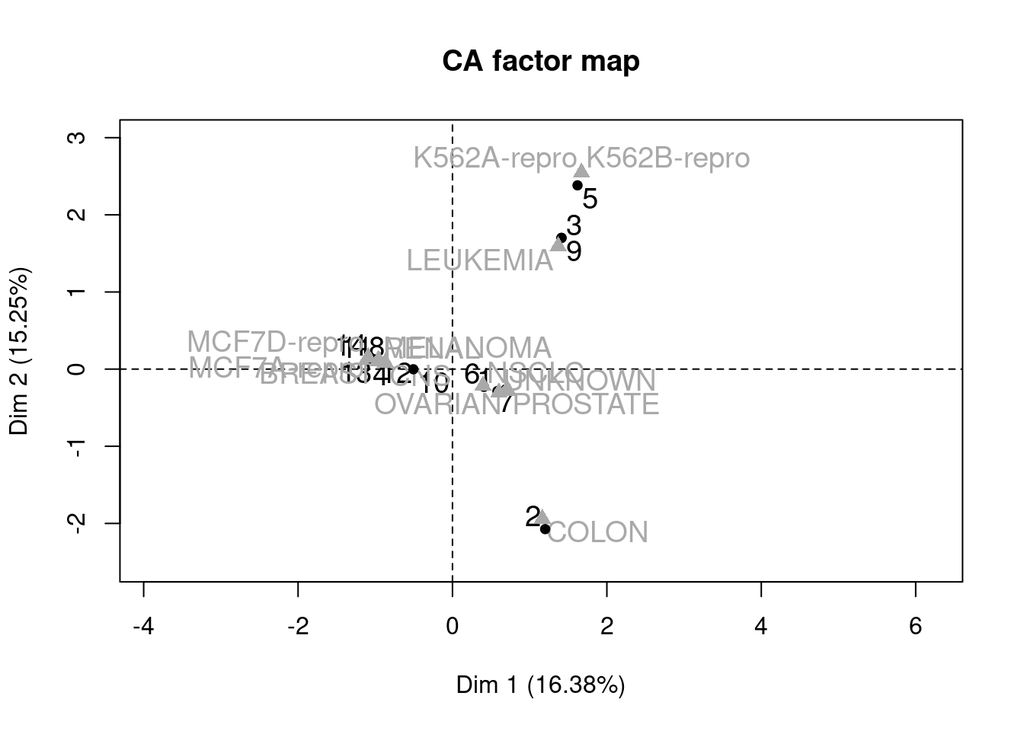

```r
## direct
#res.kpod <- kpod(X = as.matrix(xxna), k = k)
#save(res.kpod, file = "kpod_results.RData")
load("data/kpod_results.RData")

## Figure 15.2
res.ca <- CA(table(res.kpod$cluster,nci.lab), graph=FALSE)

#png("ca_clustering.png", res=300,width=2000, height=2000)
print(plot(res.ca, graph.type = "classic",cex=1.2,col.row = "black", col.col = "darkgrey",xlim = c(-1.2,3.5)))
```

```r
#dev.off()
```

Associations between the kpod partition and cancer types: Correspondence Analysis factor map. Black numbers indicate clusters obtained by kpod, while cancer types are represented by their names in grey

### Subspace clustering

We apply RKpod to NCI60 data in order to obtain a visualization of clusters, as well as a partition more robust to redundant or noised variables. Note that it could additionally allow identification of biomarkers’ subsets most relevant for patient stratification. The method is applied for a low low-rank dimension equal to 6. Missing values in RKpod are initialized using MI by PCA with r=16 dimensions seven times. Figure 15.3 reports the data projection onto the principal subspace. Compared to Figure 15.1, the projection aims to make clusters as widely dispersed as possible.

```r
# MI

# res.imp <- MIPCA(xxna, ncp = 16, scale = TRUE, nboot = 20,verbose = TRUE)
 # res.ana <- lapply(res.imp$res.MI,
 #                       FUN = KMeans_rcpp ,
 #                       clusters = k,num_init=10)
#
#save(res.imp, res.ana, file = "imp_results.RData")
load("data/imp_results.RData")

### extract the set of partitions (as list)
res.ana<- lapply(res.ana, "[[", "clusters")
### pooling by NMF
res.pool<- fastnmf(res.ana, nb.clust = k,method.init = c("BOK","kmeans"))
```

```
Initialisation by BOK  1 ...2 ...3 ...4 ...5 ...6 ...7 ...8 ...9 ...done!
Initialisation by kmeans  1 ...2 ...3 ...4 ...5 ...6 ...7 ...8 ...9 ...done!
```

[output not shown]

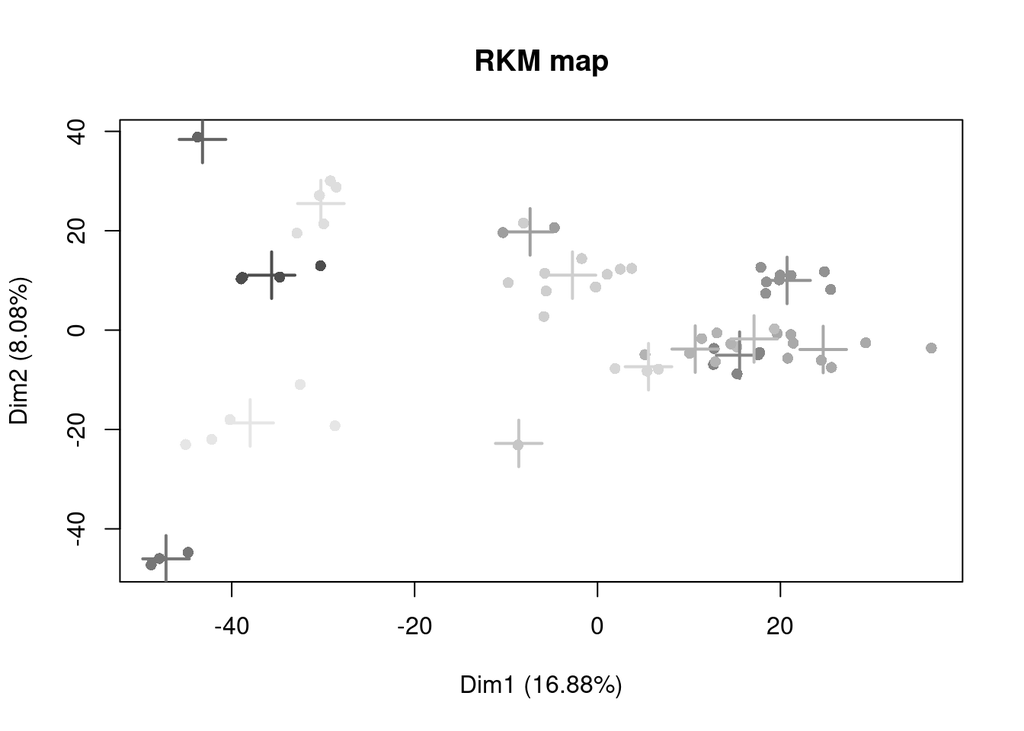

```r
part.km <- res.pool$best$clust

# rkpod
# res.rkpod <- rkpod(xxna=xxna,
#                    k=k,
#                    q=6,
#                    nnodes=7,
#                    method.init.rkpod = rep("MIPCA",7),
#                    ncp=16)
#
# save(res.rkpod, file = "rkpod_results.RData")
load("data/rkpod_results.RData")

## Figure 15.3
#png("rkpod_map.png", res=300,width=2000, height=2000)
print(plot.rkpod(res.rkpod))
```

```r
#dev.off()
```

RKpod map for NCI60 data. Points correspond to observations, while crosses correspond to centers of clusters provided by RKpod.

## The case of unique biomarkers

### Data simulation

To illustrate the implications of LOD-related missingness in biomarker-based analyses, we simulate a dataset replicating the distribution of a biomarker, in association with relevant covariates and a binary clinical outcome. We then fit a logistic regression model to examine how different imputation strategies for values below the LOD affect the estimation of prognostic effects. The simulated dataset comprises n=150 observations, with approximately 40% of biomarker values falling below the detection limit and thus not observed. This level of missingness highlights the practical challenges commonly encountered in real-life datasets.

```r
library(ggplot2)
library(ggpubr)

set.seed( 454)

N <- 150

age <- rnorm(n = N, mean = 50, sd = 20)
gender <-  rbinom(n = N, size = 1, p=0.5)
mutation <-  rbinom(n = N, size = 1, p=0.2)
biomarker <- age*0.2 + 6*gender + 6*mutation + rnorm(N, mean = 0, sd = 4)

stat <-  -2 + biomarker*0.2
proba <- plogis(stat)
ORR <- rbinom(N,1,proba)

datasim <- data.frame(age = age, gender = as.factor(gender), mutation = mutation,
                      biomarker = biomarker,
                      proba = proba,
                      ORR = ORR)
```

### Data exploration

#### Biomarker according to ORR

[output not shown]

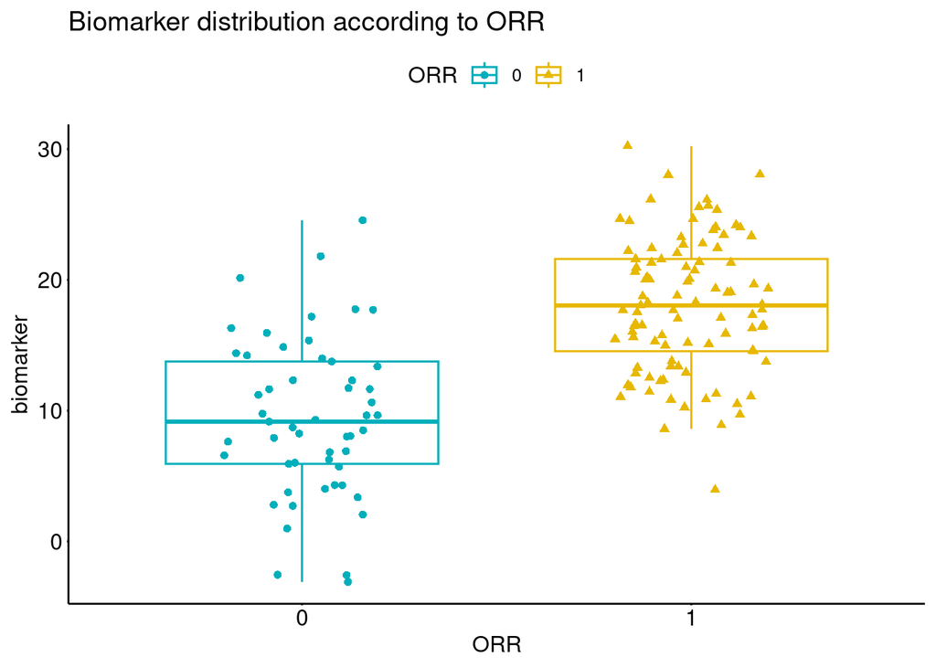

```r
corrplot <- ggboxplot(datasim, "ORR", "biomarker",
          color = "ORR", palette =c("#00AFBB", "#E7B800"),
          add = "jitter", shape = "ORR") + ggtitle("Biomarker distribution according to ORR")
corrplot
```

#### Biomarker according to age

```r
ggscatter(datasim, x = "age", y = "biomarker",
          color = "black", shape = 21, size = 3, # Points color, shape and size
          add = "reg.line",  # Add regressin line
          add.params = list(color = "blue", fill = "lightgray"), # Customize reg. line
          conf.int = TRUE, # Add confidence interval
          cor.coef = TRUE, # Add correlation coefficient. see ?stat_cor
          cor.coeff.args = list(method = "pearson", label.x = 30, label.sep = "\n")) +
            ggtitle("Biomarker according to age")
```

[output not shown]

[figure not shown]

#### Biomarker according to gender

[output not shown]

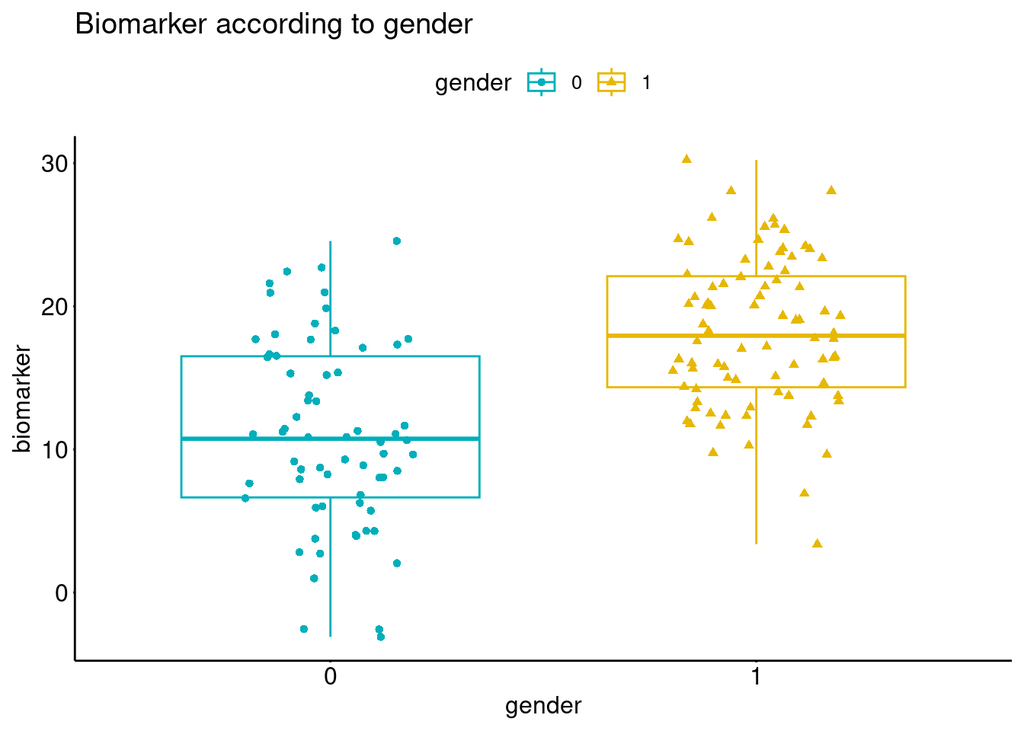

```r
ggboxplot(datasim, "gender", "biomarker",
          color = "gender", palette =c("#00AFBB", "#E7B800"),
          add = "jitter", shape = "gender")+
            ggtitle("Biomarker according to gender")
```

#### Biomarker according to mutation

[output not shown]

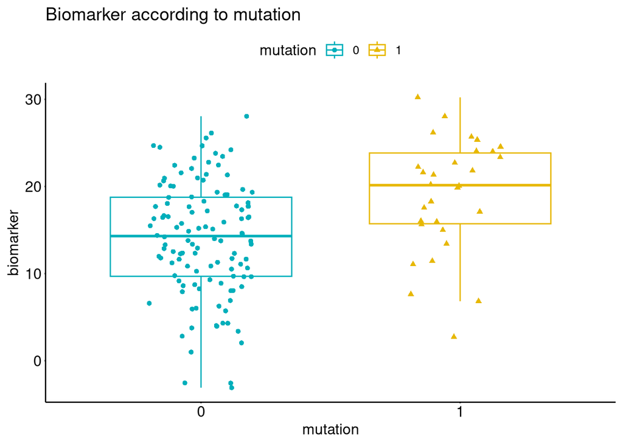

```r
ggboxplot(datasim, "mutation", "biomarker",
          color = "mutation", palette =c("#00AFBB", "#E7B800"),
          add = "jitter", shape = "mutation")+
            ggtitle("Biomarker according to mutation")
```

### Logistic regression fit figure

[output not shown]

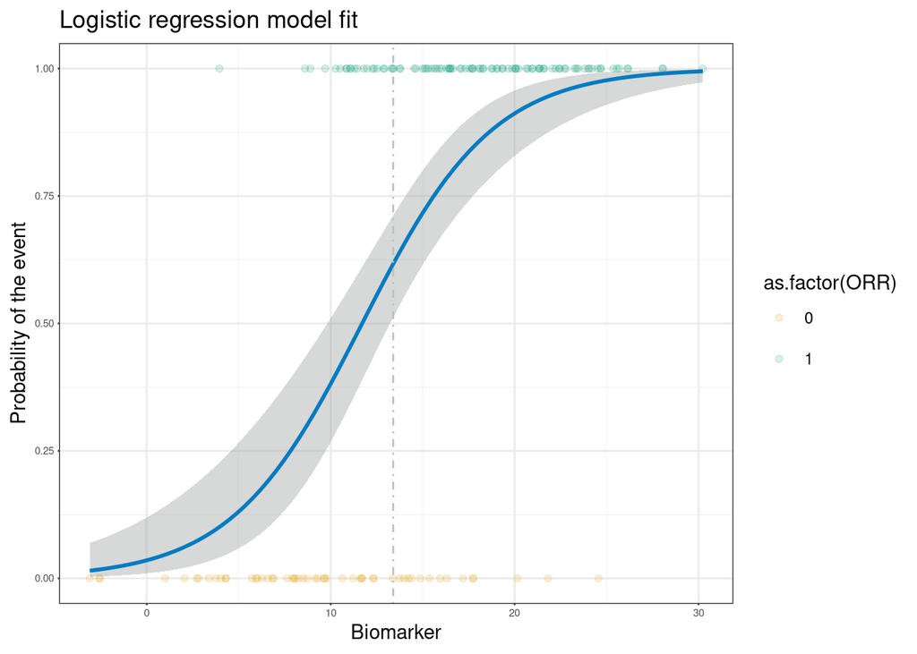

```r
LOD <- quantile(datasim$biomarker, probs = 0.4)

modelfull <- glm(ORR ~ biomarker, family = "binomial", data = datasim)
#summary(modelfull)$coef

logfit <- ggplot(data = datasim, aes(biomarker, ORR)) +
  geom_point(alpha = .15, aes(color = as.factor(ORR))) +
  geom_smooth(method = "glm", method.args = list(family = "binomial")) +
    geom_vline(xintercept = LOD, linetype="dotdash", color = "gray") +
  ggtitle("Logistic regression model fit") +
  xlab("Biomarker") +
  ylab("Probability of the event") +
    theme_bw()

logfit
```

```r
ggsave(filename = "logfit.png", plot = logfit)
```

[output not shown]

```r
# logfitbw <- ggplot(data = datasim, aes(biomarker, ORR)) +
#   geom_point(aes(color = as.factor(ORR))) +
#   geom_smooth(method = "glm", color = "black", method.args = list(family = "binomial")) +
#     geom_vline(xintercept = LOD, linetype="dotdash", color = "gray") +
#   ggtitle("Logistic regression model fit") +
#   xlab("Biomarker") +
#   ylab("Probability of the event") +
#     theme_bw() +
#   scale_color_manual(
#     name = "Response",
#     values = c("0" = "black", "1" = "gray")
#   )

#logfitbw

#ggsave(filename = "logfitbw.png", plot = logfitbw, height = 8, width = 8)
```

### Adding missing data and single imputation

[output not shown]

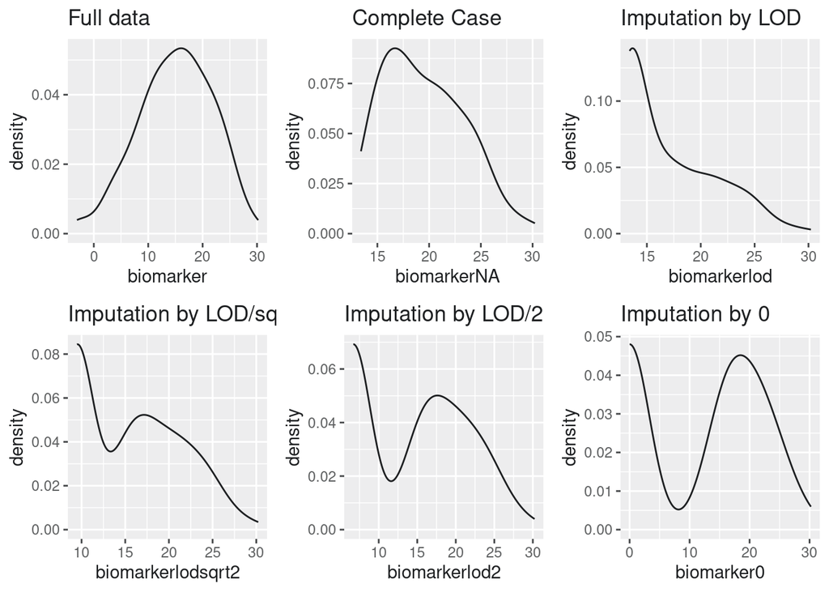

```r
library(gridExtra)

datasim$biomarkerNA  <- datasim$biomarker
datasim$biomarkerNA[datasim$biomarkerNA < LOD] <- NA
datasim$cens  <- is.na(datasim$biomarkerNA)

datasim$biomarkerlod  <- datasim$biomarker
datasim$biomarkerlod[datasim$biomarkerlod < LOD] <- LOD

datasim$biomarkerlodsqrt2  <- datasim$biomarker
datasim$biomarkerlodsqrt2[datasim$biomarkerlodsqrt2 < LOD] <- LOD/sqrt(2)

datasim$biomarkerlod2  <- datasim$biomarker
datasim$biomarkerlod2[datasim$biomarkerlod2 < LOD] <- LOD/2

datasim$biomarker0  <- datasim$biomarker
datasim$biomarker0[datasim$biomarker0 < LOD] <- 0

plot0 <-  ggplot(datasim, aes(x=biomarker0)) +
  geom_density() + ggtitle("Imputation by 0")# + xlim(-2, 10)

plotlod2 <-  ggplot(datasim, aes(x=biomarkerlod2)) +
  geom_density() +  ggtitle("Imputation by LOD/2") #xlim(0, 10) +

plotlodsqrt2 <-  ggplot(datasim, aes(x=biomarkerlodsqrt2)) +
  geom_density()  + ggtitle("Imputation by LOD/sqrt(2)") #+ xlim(0, 10)

plotlod <-  ggplot(datasim, aes(x=biomarkerlod)) +
  geom_density() + ggtitle("Imputation by LOD") #xlim(0, 10) +

plotfull <-  ggplot(datasim, aes(x=biomarker)) +
  geom_density()  + ggtitle("Full data") #+ xlim(-10, 10) + ylim(0, 0.4)

plotcomp <-  ggplot(datasim, aes(x=biomarkerNA)) +
  geom_density()  + ggtitle("Complete Case") #+ xlim(-10, 10) + ylim(0, 0.4)

grid.arrange(plotfull, plotcomp, plotlod,
             plotlodsqrt2, plotlod2, plot0,
             nrow = 2)
```

### Multiple imputation from section

```r
library(qgcomp)
library(mice)
library(dplyr)
library(tidyr)
#Imputation based on linear left censored model based on age + gender + mutation as covariate
#10 imputation in this example - could be 5 as discussed in the book

impdat <- mice::mice(data = datasim[, c("age", "gender", "mutation", "biomarkerNA")],
              method = c("", "", "", "leftcenslognorm"),
              lod=c(NA, NA, NA, LOD), debug=FALSE, m=10, print = FALSE)

mires <- as.data.frame(matrix(unlist(impdat$imp), ncol = 10))
colnames(mires) <- paste("imp", 1:10, sep ="_")

mireslong <- mires %>%
  pivot_longer(cols = starts_with("imp"),, names_to = "type", values_to = "biomarker")

mireslong <- rbind(mireslong,
                   data.frame(type = rep("biomarkercens", length = N), biomarker = datasim$biomarkerNA)) %>%
  mutate(value = case_when(type == "biomarkercens" ~ "observed",
                           .default  = "imputed"))

densitymi <- ggplot(mireslong, aes(x=biomarker, fill=type)) +
  geom_density(alpha=0.4, color = "gray") +
  scale_fill_manual(values = c("darkcyan", rep("goldenrod", 10))) +
   theme_bw()


#densitymi

ggsave(filename = "densitymi.png", plot = densitymi)
```

[output not shown]

```r
##Black and white figures for the book
bw = 1
densitymibw <- ggplot(mireslong, aes(x = biomarker, fill = type)) +
  geom_density(alpha = 0.7, bw = bw) +
  # couleurs pour chaque imputation + observed
  scale_fill_manual(
    values = c("biomarkercens" = "black", rep("gray", 10)),
    guide = "none"   # enlève la légende liée à 'type'
  ) +
  # ajoute une légende simple basée sur 'value'
  geom_density(aes(color = value), alpha = 0.7,  bw = bw) +
  scale_color_manual(
    name = "values",
    values = c("observed" = "black", "imputed" = "gray")
  ) +
  ggtitle("Comparison of Observed and Imputed Biomarker Distributions")+
  theme_publication

#densitymibw

ggsave(filename = "densitymibw.png", plot = densitymibw)
```

[output not shown]

[output not shown]

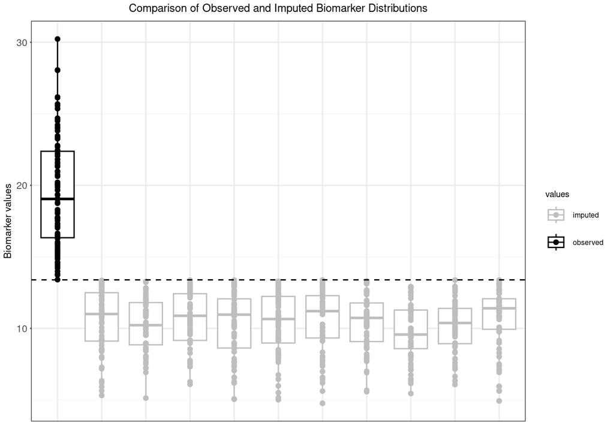

```r
boxplotmibw <- ggplot(mireslong, aes(y = biomarker, x = type, color = value)) +
  geom_boxplot(fill = "white") +
  geom_point() +
  # couleurs pour chaque imputation + observed
  scale_color_manual(
    name = "values",
    values = c("observed" = "black", "imputed" = "gray")
  ) +
  geom_hline(yintercept = LOD, color = "black", linetype = "dashed")+
  ggtitle("Comparison of Observed and Imputed Biomarker Distributions")+
  ylab("Biomarker values") + xlab("") +
  theme_publication +
  theme(
    axis.text.x = element_blank(),
    axis.ticks.x = element_blank()
  )

boxplotmibw
```

```r
ggsave(filename = "boxplot.png", plot = boxplotmibw, width = 7, height = 5)
```

[output not shown]

Censored values were imputed below the LOD, as expected, and their consistency can be checked against the distribution of observed values above the detection limit

### Descriptive analysis of left censored biomarkers

## Kaplan Meier

```r
library(NADA)
library(censReg)

##Kaplan Meier for left censored:
km <- NADA::cenfit(datasim$biomarker, datasim$cens)

##Display mean +/- se
descriptive_km <- mean(km)
descriptive_km
```

```
      mean         se    0.95LCL    0.95UCL
17.0710448  0.3479995 16.3889783 17.7531113
```

## ROS

```r
#regression on order statistics:
ros <- NADA::cenros(datasim$biomarker, is.na(datasim$cens))

#Imputed values
ros_values <- ros$modeled

#Mean & SD & SE
mean_ros <- mean(ros_values)
se_ros <- sd(ros_values) / sqrt(length(ros_values))

# 95% confidence interval
ci_lower_ros <- mean_ros - 1.96 * se_ros
ci_upper_ros <- mean_ros + 1.96 * se_ros

# Combine results
descriptive_ros <- c(mean_ros, se_ros, ci_lower_ros, ci_upper_ros)
names(descriptive_ros) <- names(descriptive_km)
descriptive_ros
```

```
      mean         se    0.95LCL    0.95UCL
15.0123870  0.5561148 13.9224021 16.1023720
```

## Tobit

```r
tobit <- censReg::censReg(datasim$biomarkerlod~1, left = LOD)

# Estimateur (moyenne)
mean_tobit <- coef(tobit)[1]

# Erreur standard associée
se_tobit <- sqrt(diag(vcov(tobit)))[1]

# Intervalle de confiance à 95%
ci_lower_tobit <- mean_tobit - 1.96 * se_tobit
ci_upper_tobit <- mean_tobit + 1.96 * se_tobit

# Combine results
descriptive_tobit <- c(mean_tobit, se_tobit, ci_lower_tobit, ci_upper_tobit)
names(descriptive_tobit) <- names(descriptive_km)
descriptive_tobit
```

```
     mean        se   0.95LCL   0.95UCL
15.271940  0.588708 14.118073 16.425808
```

### Incomplete data reporting and sensitivity assessment

Comparison with full model and single imputation

```r
#Full model
mean_full <- mean(datasim$biomarker)
se_full <- sd(datasim$biomarker) / sqrt(length(datasim$biomarker))

#Complete Case
mean_cc <- mean(datasim$biomarkerNA, na.rm = TRUE)
se_cc <- sd(datasim$biomarkerNA, na.rm = TRUE) / sqrt(sum(!is.na(datasim$biomarkerNA)))

#LOD
mean_lod <- mean(datasim$biomarkerlod, na.rm = TRUE)
se_lod <- sd(datasim$biomarkerlod, na.rm = TRUE) / sqrt(length(datasim$biomarkerlod))

#LOD/2
mean_lod2 <- mean(datasim$biomarkerlod2)
se_lod2 <- sd(datasim$biomarkerlod2) / sqrt(length(datasim$biomarkerlod2))


#LOD/sqrt(2)
mean_lodsqrt2 <- mean(datasim$biomarkerlodsqrt2)
se_lodsqrt2 <- sd(datasim$biomarkerlodsqrt2) / sqrt(length(datasim$biomarkerlodsqrt2))

#0
mean_0 <- mean(datasim$biomarker0)
se_0 <- sd(datasim$biomarker0) / sqrt(length(datasim$biomarker0))



# creating a data frame and adding the 95% confidence interval
descriptive <- data.frame(mean = c(mean_full, mean_cc, mean_lod, mean_lod2, mean_lodsqrt2, mean_0),
                   se = c(se_full, se_cc, se_lod, se_lod2, se_lodsqrt2, se_0))

descriptive$ci_lower <- descriptive$mean - 1.96 * descriptive$se
descriptive$ci_upper <- descriptive$mean + 1.96 * descriptive$se


descriptive <- as.data.frame(rbind(descriptive,
                     descriptive_km,
                   descriptive_ros,
                   descriptive_tobit
                   ))

descriptive$label <- c("Full data", "Complete Case", "LOD imputation",
                        "LOD/2 imputation", "LOD/sqrt(2) imputation", "0 imputation",
                       "Kaplan Meier", "ROS", "Tobit")
descriptive$index <- c(1, 2, 3, 4, 5, 6, 7, 8, 9)

##Forest plot to compare results
forestplotmean <- ggplot(descriptive, aes(y = index, x = mean)) +
  geom_point(shape = 18, size = 5) +
  geom_errorbarh(aes(xmin = ci_lower , xmax = ci_upper), height = 0.25) +
  geom_vline(xintercept = mean_full, color = "red", linetype = "dashed", cex = 1, alpha = 0.5) +
  scale_y_continuous(name = "", breaks=1:9, labels = descriptive$label, trans = "reverse") +
  xlab("Mean (95% CI)") +
  ylab(" ") +
  theme_bw() +
  theme(panel.border = element_blank(),
        #panel.background = element_blank(),
        #panel.grid.major = element_blank(),
        #panel.grid.minor = element_blank(),
        axis.line = element_line(colour = "black"),
        axis.text.y = element_text(size = 12, colour = "black"),
        axis.text.x.bottom = element_text(size = 12, colour = "black"),
        axis.title.x = element_text(size = 12, colour = "black")) +
  ggtitle("mean estimation according to missing data handling")

#forestplotmean


ggsave(filename = "forestplotmean2.png", plot = forestplotmean, width = 12, height = 8 )
```

[output not shown]

```r
##fit with full data:
modelfull <- glm(ORR ~ biomarker, family = "binomial", data = datasim)
##fit with complete case:
modelcomp <- glm(ORR ~ biomarkerNA, family = "binomial", data = datasim)
##fit with LOD:
modellod <- glm(ORR ~ biomarkerlod, family = "binomial", data = datasim)
##fit with LOD/2:
modellod2 <- glm(ORR ~ biomarkerlod2, family = "binomial", data = datasim)
##fit with LOD/sqrt2:
modellodsqrt2 <- glm(ORR ~ biomarkerlodsqrt2, family = "binomial", data = datasim)
##fit with 0:
model0 <- glm(ORR ~ biomarker0, family = "binomial", data = datasim)
##fit MI:
fit.imp.log <- impdat %>%
  with(glm(ORR ~ biomarkerNA, family = "binomial"))

modelMI <- pool(fit.imp.log)
```

```r
##Combine results
logisticdata <- as.data.frame(rbind(summary(modelfull)$coef[2, ],
                      summary(modelcomp)$coef[2, ],
                      summary(modellod)$coef[2, ],
                      summary(modellod2)$coef[2, ],
                      summary(modellodsqrt2)$coef[2, ],
                      summary(model0)$coef[2, ],
                      summary(modelMI)[2, c("estimate", "std.error", "statistic", "p.value")]))

#Renaiming because of different convention between mice and glm
rownames(logisticdata) <- c("full", "complete", "lod", "lod2", "lodsqrt2", "0", "MI")
colnames(logisticdata) <- names(summary(modelfull)$coef[2, ])

logisticdata$LL <- logisticdata$Estimate - qt(0.975,df=N-1)*logisticdata$`Std. Error`/sqrt(N)
logisticdata$UL <- logisticdata$Estimate + qt(0.975,df=N-1)*logisticdata$`Std. Error`/sqrt(N)
logisticdata$IC <- paste(round(logisticdata$LL, 2),
                         round(logisticdata$UL, 2), sep = ", ")
logisticdata$label <- c("Full data", "Complete Case", "LOD imputation",
                        "LOD/2 imputation", "LOD/sqrt(2) imputation", "0 imputation", "Multiple imputation")
logisticdata$index <- c(1, 2, 3, 4, 5, 6, 7)

logisticdata
```

```
          Estimate Std. Error  z value     Pr(>|z|)        LL        UL
full     0.2821961 0.04757263 5.931901 2.994478e-09 0.2745207 0.2898715
complete 0.2562541 0.10354378 2.474838 1.332965e-02 0.2395483 0.2729600
lod      0.4009093 0.08277498 4.843364 1.276591e-06 0.3875544 0.4142643
lod2     0.2019581 0.03466359 5.826230 5.669332e-09 0.1963654 0.2075507
lodsqrt2 0.2603307 0.04635288 5.616278 1.951142e-08 0.2528521 0.2678093
0        0.1293200 0.02162456 5.980237 2.228134e-09 0.1258311 0.1328089
MI       0.2901524 0.05723854 5.069179 2.358280e-06 0.2809175 0.2993873
                 IC                  label index
full     0.27, 0.29              Full data     1
complete 0.24, 0.27          Complete Case     2
lod      0.39, 0.41         LOD imputation     3
lod2      0.2, 0.21       LOD/2 imputation     4
lodsqrt2 0.25, 0.27 LOD/sqrt(2) imputation     5
0        0.13, 0.13           0 imputation     6
MI        0.28, 0.3    Multiple imputation     7
```

```r
##Forest plot
forestplot <- ggplot(logisticdata, aes(y = index, x = Estimate)) +
  geom_point(shape = 18, size = 5, color = "black") +
  geom_errorbarh(aes(xmin = LL, xmax = UL), height = 0.25, color = "black") +
  geom_vline(xintercept = summary(modelfull)$coef[2, 1], color = "red", linetype = "dashed", cex = 1, alpha = 0.5) +
  scale_y_continuous(name = "", breaks=1:7, labels = logisticdata$label, trans = "reverse") +
  xlab("Odds Ratio (95% CI)") +
  ylab(" ") +
  theme_bw() +
  # theme(panel.border = element_blank(),
  #       panel.background = element_blank(),
  #       panel.grid.major = element_blank(),
  #       panel.grid.minor = element_blank(),
  #       axis.line = element_line(colour = "black"),
  #       axis.text.y = element_text(size = 12, colour = "black"),
  #       axis.text.x.bottom = element_text(size = 12, colour = "black"),
  #       axis.title.x = element_text(size = 12, colour = "black")) +
  ggtitle("Logistic fit according to missing data handling")

#forestplot

ggsave(filename = "forestplot.png", plot = forestplot)
```

[output not shown]

[output not shown]

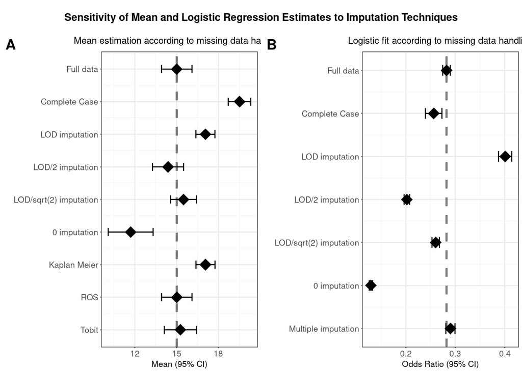

```r
library(cowplot)

forestplotbw <- ggplot(logisticdata, aes(y = index, x = Estimate)) +
  geom_point(shape = 18, size = 5, color = "black") +
  geom_errorbarh(aes(xmin = LL, xmax = UL), height = 0.25, color = "black") +
  geom_vline(xintercept = summary(modelfull)$coef[2, 1], color = "black", linetype = "dashed", cex = 1, alpha = 0.5) +
  scale_y_continuous(name = "", breaks=1:7, labels = logisticdata$label, trans = "reverse") +
  xlab("Odds Ratio (95% CI)") +
  ylab(" ") +
  theme_publication +
  ggtitle("Logistic fit according to missing data handling")

#forestplotbw

forestplotmeanbw <- ggplot(descriptive, aes(y = index, x = mean)) +
  geom_point(shape = 18, size = 5, color = "black") +
  geom_errorbarh(aes(xmin = ci_lower , xmax = ci_upper), height = 0.25, color = "black") +
  geom_vline(xintercept = mean_full, color = "black", linetype = "dashed", cex = 1, alpha = 0.5) +
  scale_y_continuous(name = "", breaks=1:9, labels = descriptive$label, trans = "reverse") +
  xlab("Mean (95% CI)") +
  ylab(" ") +
   theme_publication +
  ggtitle("Mean estimation according to missing data handling")

#forestplotmeanbw

# Combining 2 plots
forest_combined_plot <- plot_grid(forestplotmeanbw, forestplotbw,
                           labels = c("A", "B"),
                           ncol = 2, align = "h")

# Titre global
title <- ggdraw() +
  draw_label("Sensitivity of Mean and Logistic Regression Estimates to Imputation Techniques", fontface = 'bold', x = 0.5, hjust = 0.5, size = 10)

final_plot <- plot_grid(title, forest_combined_plot, ncol = 1, rel_heights = c(0.1, 1))
plotforchapter <- plot_grid(forest_combined_plot, ncol = 1, rel_heights = c(0.1, 1))

# Affichage
final_plot
```

```r
#plotforchapter
# Sauvegarde
ggsave("forest_combined_plot.png", plotforchapter, width = 10, height = 4, dpi = 300)
```

[output not shown]

This figure summarizes how different strategies for handling censored biomarker values affect both the estimated mean level and the inferred prognostic association with clinical outcome. The dashed line indicates the reference estimate from the complete dataset before censoring. Naive substitutions (e.g., zeros) or complete case analysis distort the estimates, leading to marked under- or overestimation. Despite their simplicity, substitution methods using LOD/2 or LOD/√2 perform better here, providing estimates closer to the reference value. Model-based approaches (e.g., Tobit regression, ROS, multiple imputation) yield estimates most consistent with the full data, highlighting their ability to appropriately account for censoring. In contrast, Kaplan–Meier imputation tends to overestimate the mean in this setting.